## Camera trap contrasts

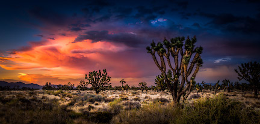

### Introduction

Rapid, simple tools that sample a population are critical to effective ecological research particularly in dryland ecosystems where populations are relatively dispersed and at low densities. Here, we explored the efficacy of camera traps to examine plant-animal interactions in two distinct desert ecosystems. The Mojave National Preserve and The Carrizo National Monument were sampled in the spring 2017 season for patterns animal activity. The fundamental ecological hypothesis examined was that foundation plant species can function as benefactors to other taxa such as vertebrate animals.

### Methods & meta-data

Camera traps were deployed to explore the ecological function of foundation plant species such as shrubs or cacti on desert animals. In the Carrizo, *Ephedra californica* was used as the foundation species, and in the Mojave, Larrea tridentata and Cylindropuntia acanthocarpa were used to structure sampling. An ‘open’ microsite control was used in the Carrizo to provide an estimate of the relative importance of associational patterns with shrubs.

### Data

Data were collected in dataframes from the camtraps at each desert site. Foundation plant data were also collected in addition to basic eccological descriptions of the local environmental contexts.

```r
library(tidyverse)
library(skimr)
#sites & foundation species
cnm <- read_csv("data/2017 carrizo camtrap-veg.csv")
cnm$camtrap.label <- as.character(cnm$camtrap.label)
mnp <- read_csv("data/2017 MNP camtrap-veg.csv")

sites <- bind_rows(cnm, mnp)
sites <- sites %>%
  mutate(volume = ((x + y)/2)^3*3.14*(1/3))
sites$rep <- as.character(sites$rep)

#animals
cnm.cams <- read_csv("data/2017 carrizo camtraps.csv")
mnp.cams <- read_csv("data/2017 MNP camtraps.csv")

cnm.cams$actual.time <- as.numeric(cnm.cams$actual.time)
cnm.cams$temp <- as.numeric(cnm.cams$temp)


mnp.cams$actual.time <- as.numeric(mnp.cams$actual.time)
cams <- bind_rows(cnm.cams, mnp.cams)
skim(cams)
```

```
## Skim summary statistics
##  n obs: 312110
##  n variables: 16
##
## Variable type: character
##      variable missing complete      n min max empty n_unique
##        animal  100966   211144 312110   1  53     0       76
##          date       0   312110 312110   6  10     0      129
##     microsite       0   312110 312110   4   8     0        4
##     night.day  308433     3677 312110   3   7     0        3
##  observations  311550      560 312110   2  66     0      171
##        region       0   312110 312110   3   3     0        2
##          site       0   312110 312110   6   7     0        2
##     timeblock  308432     3678 312110   3   9     0       14
##
## Variable type: integer
##        variable missing complete      n      mean       sd   p0   p25
##  animal.capture       3   312107 312110     0.012     0.11    0     0
##             day   39707   272403 312110    11.64      8.74    1     4
##       photo.rep       0   312110 312110 35757.06  24560.05    1 15606
##             rep   39708   272402 312110     7.4       6.03    1     3
##            week       1   312109 312110     2.31      0.82    1     2
##            year       0   312110 312110  2017         0    2017  2017
##    p50      p75  p100     hist
##      0     0        1 ▇▁▁▁▁▁▁▁
##     10    18       42 ▇▅▃▂▂▁▁▁
##  31788 52008.75 99999 ▇▇▇▆▅▃▂▂
##      6    10       32 ▇▅▂▃▁▁▁▁
##      3     3        3 ▃▁▁▃▁▁▁▇
##   2017  2017     2017 ▁▁▁▇▁▁▁▁
##
## Variable type: numeric
##     variable missing complete      n     mean       sd  p0   p25   p50
##  actual.time  310696     1414 312110 44537.1  24822.83   0 25110 40020
##         temp  308454     3656 312110    29.86    29.25 -92     8    18
##    p75  p100     hist
##  67605 86340 ▆▅▇▇▃▅▇▆
##     41   377 ▁▇▆▁▁▁▁▁
```

```r
#summary data
data <- cams %>%
  group_by(site, microsite, week, rep) %>%
  summarise(captures = sum(animal.capture), n = n()) %>% mutate(rate = captures/n)
data$rep <- as.character(data$rep)

#add size data
simpler.data <- data %>% rename(species = microsite) %>% filter(species != "open")
simpler.sites <- sites %>%
  select(species, week, rep, z, volume)
full.data <- left_join(simpler.data, simpler.sites, by = c("species", "week", "rep"))
```

### Viz

[figure not shown]

```r
#map####
require(ggmap)
cali <- get_map(location = c(lon = -118, lat = 35), zoom = 7)
p <-ggmap(cali)
p + geom_point(data=sites, aes(x=long, y=lat), alpha = 0.5, size = 4) + labs(x ="longitude", y = "latitude")
```

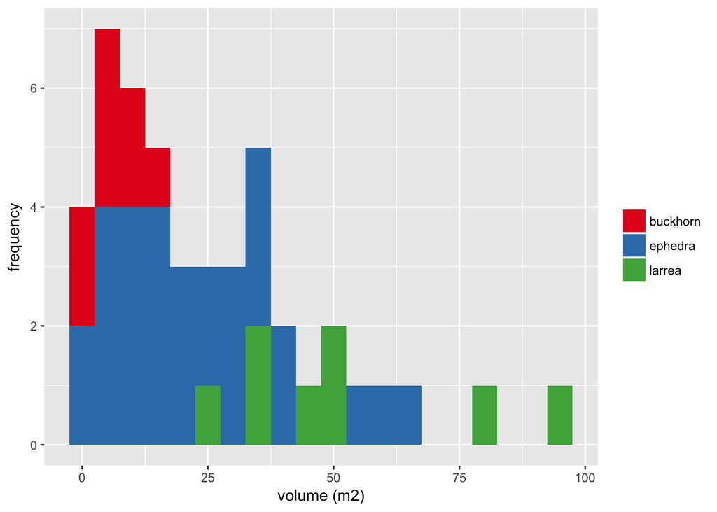

```r
#foundation species sizes####
ggplot(sites, aes(volume, fill = species)) +
         geom_histogram(binwidth = 5) +
  scale_fill_brewer(palette = "Set1") +
  labs(fill = "", x = "volume (m2)", y = "frequency")
```

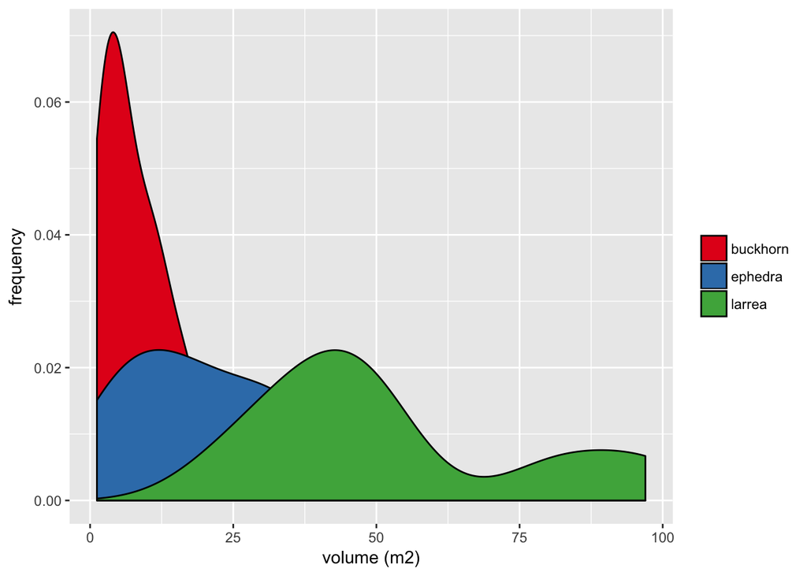

```r
ggplot(sites, aes(volume, fill = species)) +
         geom_density() +
  scale_fill_brewer(palette = "Set1") +
  labs(fill = "", x = "volume (m2)", y = "frequency")
```

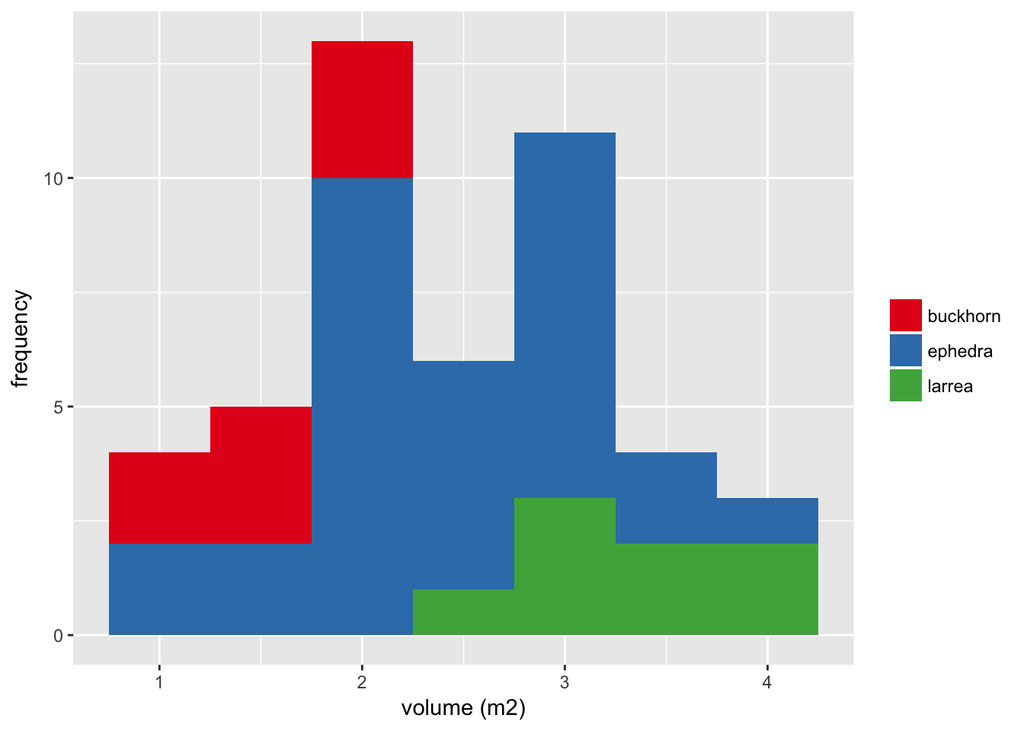

```r
ggplot(sites, aes(y, fill = species)) +
         geom_histogram(binwidth = .5) +
  scale_fill_brewer(palette = "Set1") +
  labs(fill = "", x = "volume (m2)", y = "frequency")
```

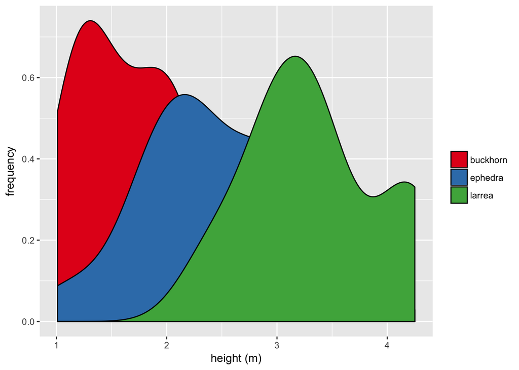

```r
ggplot(sites, aes(y, fill = species)) +
         geom_density() +
  scale_fill_brewer(palette = "Set1") +
  labs(fill = "", x = "height (m)", y = "frequency")
```

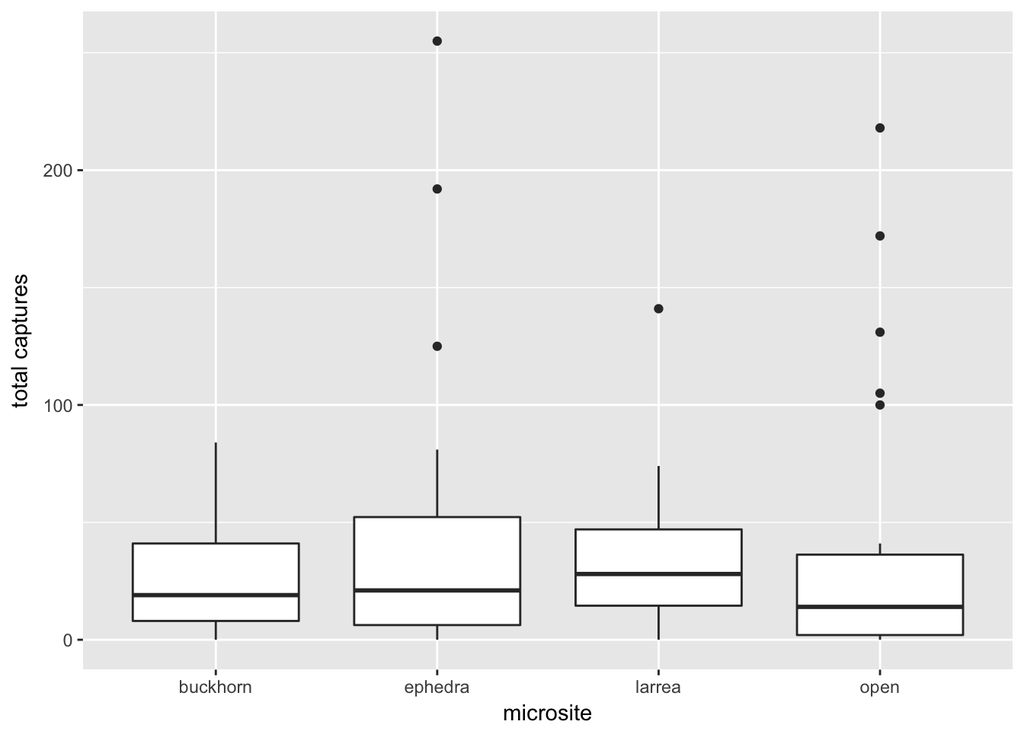

```r
#camera traps####
ggplot(data, aes(microsite, captures)) +
  geom_boxplot() +
  labs(y = "total captures")
```

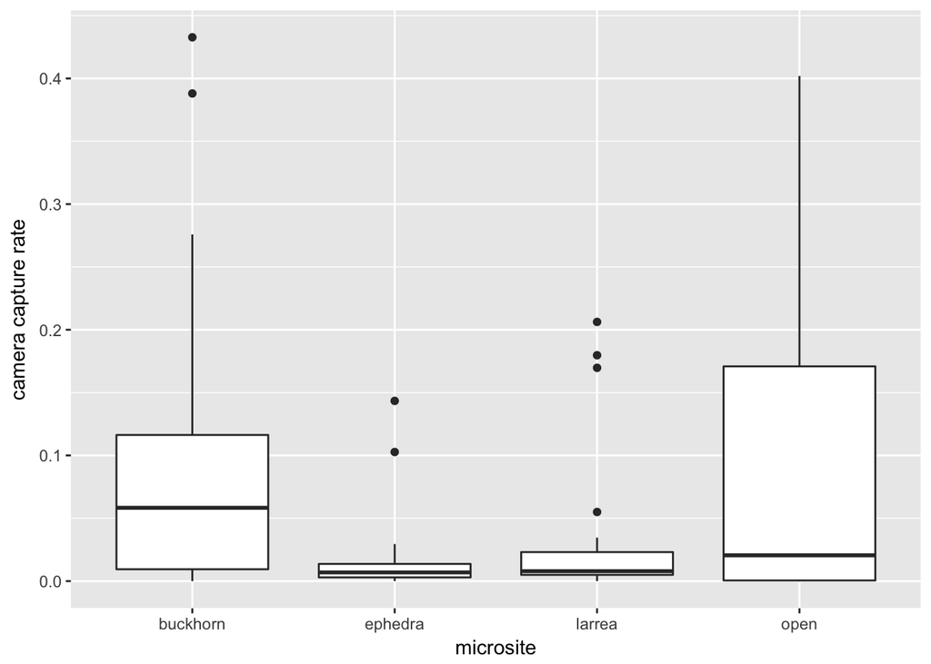

```r
ggplot(data, aes(microsite, rate)) +
  geom_boxplot() +
  labs(y = "camera capture rate")
```

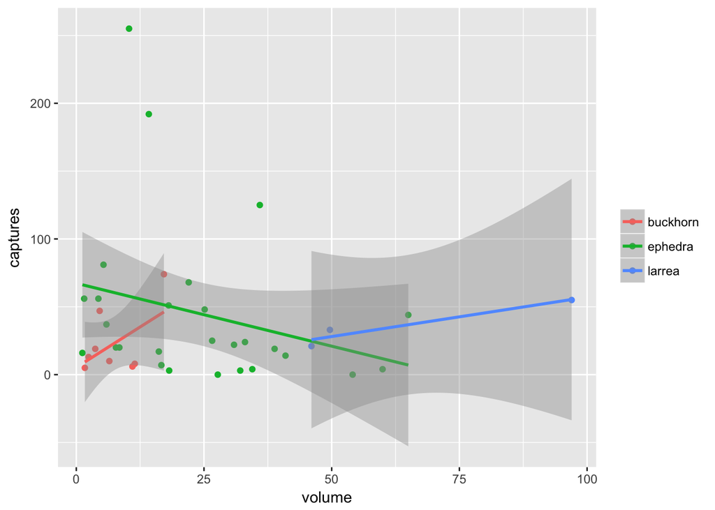

```r
ggplot(full.data, aes(volume, captures, color = species)) +
         geom_point() +
  geom_smooth(method = lm) +
  labs(color = "")
```